# Visualizacion de datos ggplot2

```r
summary(infoPowers)
```

```
##   hero_names          Agility          Accelerated.Healing Lantern.Power.Ring
##  Length:667         Length:667         Length:667          Length:667
##  Class :character   Class :character   Class :character    Class :character
##  Mode  :character   Mode  :character   Mode  :character    Mode  :character
##  Dimensional.Awareness Cold.Resistance     Durability          Stealth
##  Length:667            Length:667         Length:667         Length:667
##  Class :character      Class :character   Class :character   Class :character
##  Mode  :character      Mode  :character   Mode  :character   Mode  :character
##  Energy.Absorption     Flight          Danger.Sense       Underwater.breathing
##  Length:667         Length:667         Length:667         Length:667
##  Class :character   Class :character   Class :character   Class :character
##  Mode  :character   Mode  :character   Mode  :character   Mode  :character
##  Marksmanship       Weapons.Master     Power.Augmentation Animal.Attributes
##  Length:667         Length:667         Length:667         Length:667
##  Class :character   Class :character   Class :character   Class :character
##  Mode  :character   Mode  :character   Mode  :character   Mode  :character
##   Longevity         Intelligence       Super.Strength     Cryokinesis
##  Length:667         Length:667         Length:667         Length:667
##  Class :character   Class :character   Class :character   Class :character
##  Mode  :character   Mode  :character   Mode  :character   Mode  :character
##   Telepathy         Energy.Armor       Energy.Blasts      Duplication
##  Length:667         Length:667         Length:667         Length:667
##  Class :character   Class :character   Class :character   Class :character
##  Mode  :character   Mode  :character   Mode  :character   Mode  :character
##  Size.Changing      Density.Control      Stamina          Astral.Travel
##  Length:667         Length:667         Length:667         Length:667
##  Class :character   Class :character   Class :character   Class :character
##  Mode  :character   Mode  :character   Mode  :character   Mode  :character
##  Audio.Control       Dexterity           Omnitrix         Super.Speed
##  Length:667         Length:667         Length:667         Length:667
##  Class :character   Class :character   Class :character   Class :character
##  Mode  :character   Mode  :character   Mode  :character   Mode  :character
##   Possession        Animal.Oriented.Powers Weapon.based.Powers
##  Length:667         Length:667             Length:667
##  Class :character   Class :character       Class :character
##  Mode  :character   Mode  :character       Mode  :character
##  Electrokinesis     Darkforce.Manipulation Death.Touch
##  Length:667         Length:667             Length:667
##  Class :character   Class :character       Class :character
##  Mode  :character   Mode  :character       Mode  :character
```

[output cut: 125 more lines]

```
##  Length:667         Length:667         Length:667          Length:667
##  Class :character   Class :character   Class :character    Class :character
##  Mode  :character   Mode  :character   Mode  :character    Mode  :character
##  Vision...X.Ray     Vision...Thermal   Web.Creation       Reality.Warping
##  Length:667         Length:667         Length:667         Length:667
##  Class :character   Class :character   Class :character   Class :character
##  Mode  :character   Mode  :character   Mode  :character   Mode  :character
##   Odin.Force        Symbiote.Costume   Speed.Force        Phoenix.Force
##  Length:667         Length:667         Length:667         Length:667
##  Class :character   Class :character   Class :character   Class :character
##  Mode  :character   Mode  :character   Mode  :character   Mode  :character
##  Molecular.Dissipation Vision...Cryo      Omnipresent         Omniscient
##  Length:667            Length:667         Length:667         Length:667
##  Class :character      Class :character   Class :character   Class :character
##  Mode  :character      Mode  :character   Mode  :character   Mode  :character
```

```r
summary(infoStats)
```

```
##      Name            Alignment          Intelligence      Strength
##  Length:611         Length:611         Min.   :  1.0   Min.   :  1.00
##  Class :character   Class :character   1st Qu.:  1.0   1st Qu.:  1.00
##  Mode  :character   Mode  :character   Median : 50.0   Median : 10.00
##                                        Mean   : 44.5   Mean   : 29.08
##                                        3rd Qu.: 75.0   3rd Qu.: 53.00
##                                        Max.   :113.0   Max.   :100.00
##      Speed          Durability         Power            Combat
##  Min.   :  1.00   Min.   :  1.00   Min.   :  0.00   Min.   :  1.00
##  1st Qu.:  1.00   1st Qu.:  1.00   1st Qu.:  0.00   1st Qu.:  1.00
##  Median : 23.00   Median : 32.00   Median : 37.00   Median : 50.00
##  Mean   : 27.31   Mean   : 41.84   Mean   : 40.31   Mean   : 43.21
##  3rd Qu.: 42.00   3rd Qu.: 80.00   3rd Qu.: 67.00   3rd Qu.: 70.00
##  Max.   :100.00   Max.   :120.00   Max.   :100.00   Max.   :101.00
##      Total
##  Min.   :  5.0
##  1st Qu.:  5.0
##  Median :255.0
##  Mean   :226.3
##  3rd Qu.:351.5
##  Max.   :581.0
```

```r
summary(bd)
```

```
##        ID           Gender             Taxon             Home.range
##  Min.   :  1.0   Length:462         Length:462         Min.   :-4.4400
##  1st Qu.:116.2   Class :character   Class :character   1st Qu.:-2.1275
##  Median :231.5   Mode  :character   Mode  :character   Median :-0.7100
##  Mean   :231.5                                         Mean   :-0.5516
##  3rd Qu.:346.8                                         3rd Qu.: 0.6550
##  Max.   :462.0                                         Max.   : 5.6900
##       Mass             Diet           Environment
##  Min.   :-2.3800   Length:462         Length:462
##  1st Qu.:-0.8300   Class :character   Class :character
##  Median : 0.2400   Mode  :character   Mode  :character
##  Mean   : 0.2419
##  3rd Qu.: 1.1300
##  Max.   : 4.5200
```

Informacion General sobre los personajes

```r
###--- Data ----
head(infoCharacters)
```

```
##   X          name Gender Eye.color              Race Hair.color Height
## 1 0        A-Bomb   Male    yellow             Human    No Hair    203
## 2 1    Abe Sapien   Male      blue     Icthyo Sapien    No Hair    191
## 3 2      Abin Sur   Male      blue           Ungaran    No Hair    185
## 4 3   Abomination   Male     green Human / Radiation    No Hair    203
## 5 4       Abraxas   Male      blue     Cosmic Entity      Black    -99
## 6 5 Absorbing Man   Male      blue             Human    No Hair    193
##           Publisher Skin.color Alignment Weight
## 1     Marvel Comics       <NA>      good    441
## 2 Dark Horse Comics       blue      good     65
## 3         DC Comics        red      good     90
## 4     Marvel Comics       <NA>       bad    441
## 5     Marvel Comics       <NA>       bad    -99
## 6     Marvel Comics       <NA>       bad    122
```

Informacion sobre los poderes

```r
head(infoPowers)
```

```
##    hero_names Agility Accelerated.Healing Lantern.Power.Ring
## 1     3-D Man    True               False              False
## 2      A-Bomb   False                True              False
## 3  Abe Sapien    True                True              False
## 4    Abin Sur   False               False               True
## 5 Abomination   False                True              False
## 6     Abraxas   False               False              False
##   Dimensional.Awareness Cold.Resistance Durability Stealth Energy.Absorption
## 1                 False           False      False   False             False
## 2                 False           False       True   False             False
## 3                 False            True       True   False             False
## 4                 False           False      False   False             False
## 5                 False           False      False   False             False
## 6                  True           False      False   False             False
##   Flight Danger.Sense Underwater.breathing Marksmanship Weapons.Master
```

[output cut: 230 more lines]

Caracteristicas particulares como inteligencia, fuerza y velocidad.

```r
head(infoStats)
```

```
##          Name Alignment Intelligence Strength Speed Durability Power Combat
## 1     3-D Man      good           50       31    43         32    25     52
## 2      A-Bomb      good           38      100    17         80    17     64
## 3  Abe Sapien      good           88       14    35         42    35     85
## 4    Abin Sur      good           50       90    53         64    84     65
## 5 Abomination       bad           63       80    53         90    55     95
## 6     Abraxas       bad           88      100    83         99   100     56
##   Total
## 1   233
## 2   316
## 3   299
## 4   406
## 5   436
## 6   526
```

## PROCESAMIENTO DE DATOS

Vamos a hacer un poco de procesamiento con los datos para poder hacer las figuras.

```r
###--- PROCESAMIENTO DE DATOS----
colnames(infoCharacters)[colnames(infoCharacters) == "name"] <- "Name"
colnames(infoPowers)[colnames(infoPowers) == "hero_names"] <- "Name"
unique(infoCharacters$Publisher)
```

```
##  [1] "Marvel Comics"     "Dark Horse Comics" "DC Comics"
##  [4] "NBC - Heroes"      "Wildstorm"         "Image Comics"
##  [7] ""                  "Icon Comics"       "SyFy"
## [10] "Hanna-Barbera"     "George Lucas"      "Team Epic TV"
## [13] "South Park"        "HarperCollins"     "ABC Studios"
## [16] "Universal Studios" "Star Trek"         "IDW Publishing"
## [19] "Shueisha"          "Sony Pictures"     "J. K. Rowling"
## [22] "Titan Books"       "Rebellion"         "Microsoft"
## [25] "J. R. R. Tolkien"
```

```r
marvelDcInfo <- infoCharacters[(infoCharacters$Publisher == "Marvel Comics" | infoCharacters$Publisher == "DC Comics"), ]

marvelDcInfo <- marvelDcInfo[!duplicated(marvelDcInfo$Name), ]

marvelDcInfo <- marvelDcInfo %>%
  select(Name, Gender, Race, Publisher)

marvelDcStatsInfo <- left_join(marvelDcInfo, infoStats, by = "Name")
head(marvelDcStatsInfo)[1:5]
```

```
##            Name Gender              Race     Publisher Alignment
## 1        A-Bomb   Male             Human Marvel Comics      good
## 2      Abin Sur   Male           Ungaran     DC Comics      good
## 3   Abomination   Male Human / Radiation Marvel Comics       bad
## 4       Abraxas   Male     Cosmic Entity Marvel Comics       bad
## 5 Absorbing Man   Male             Human Marvel Comics      <NA>
## 6  Adam Strange   Male             Human     DC Comics      good
```

```r
fullMarvelDc <- left_join(marvelDcStatsInfo, infoPowers, by = "Name")
head(fullMarvelDc)[1:5]
```

```
##            Name Gender              Race     Publisher Alignment
## 1        A-Bomb   Male             Human Marvel Comics      good
## 2      Abin Sur   Male           Ungaran     DC Comics      good
## 3   Abomination   Male Human / Radiation Marvel Comics       bad
## 4       Abraxas   Male     Cosmic Entity Marvel Comics       bad
## 5 Absorbing Man   Male             Human Marvel Comics      <NA>
## 6  Adam Strange   Male             Human     DC Comics      good
```

```r
fullMarvelDc$Name <- as.factor(fullMarvelDc$Name)
fullMarvelDc$Gender <- as.factor(fullMarvelDc$Gender)
fullMarvelDc$Race <- as.factor(fullMarvelDc$Race)
fullMarvelDc$Publisher <- as.factor(fullMarvelDc$Publisher)
fullMarvelDc$Alignment <- as.factor(fullMarvelDc$Alignment)

marvelDcGender <- fullMarvelDc %>% filter(!is.na(Gender)) %>%
  group_by(Gender)%>%
  dplyr::count(Publisher) %>%
  select(Gender, Publisher, Count = n)
```

## GRAFICAS BASICAS

### BASE DEL GRAFICO

Vamos a empezar con las graficas basicas de ggplot

```r
###--- Graficas basicas ----

# 1. Base del grafico
# ggplot con dos elementos basicos:
#    - 1) la base de datos y
#    - 2) los elementos esteticos.
# ggplot de forma predeterminada muestra las coordenadas y el tema.
```

El primer argumento que le debes de dar primero es `data`, luego mapeamos los elementos visuales a las columnas

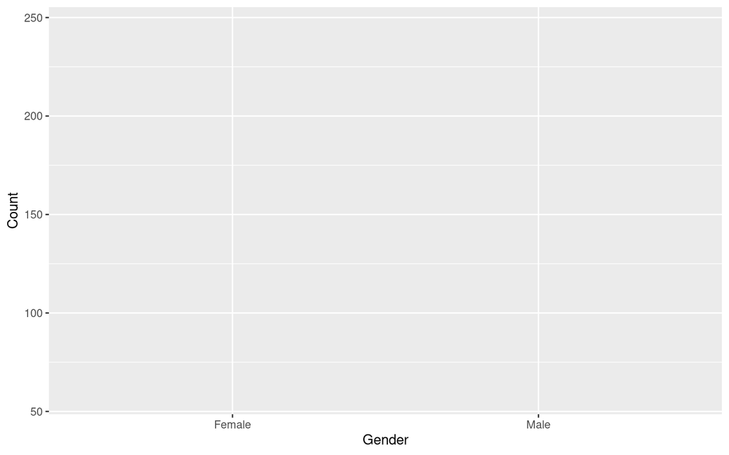

```r
ggplot(data = marvelDcGender, mapping = aes(x = Gender, y = Count))
```

Establecimos a `x` como `Gender` y a `y` como `Count`, pero podras notar que no hay ninguna figura en el plot, el siguiente paso es agregar la geometria de puntos.

### GEOMETRIA DE PUNTOS

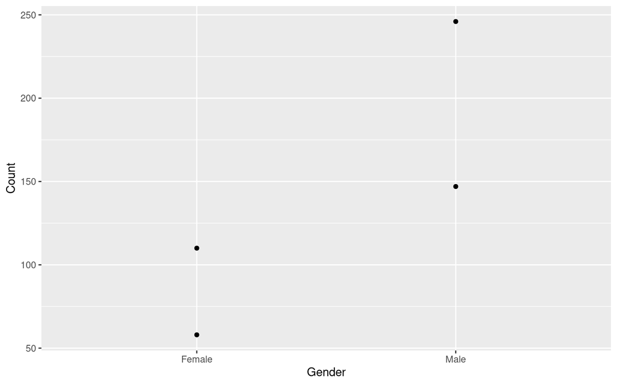

```r
#2. Se agregan las geometrias
# aes(), en este caso las variables (x, y)
# Tipo de grafica = que queremos representar y agregamos el tipo de geometria para representar los datos.
# aplicar a todo el grafico y a las capas siguientes el mapping (overide posible)
ggplot(data = marvelDcGender) +
    geom_point(mapping = aes(x = Gender, y = Count)) # Grafica de puntos
```

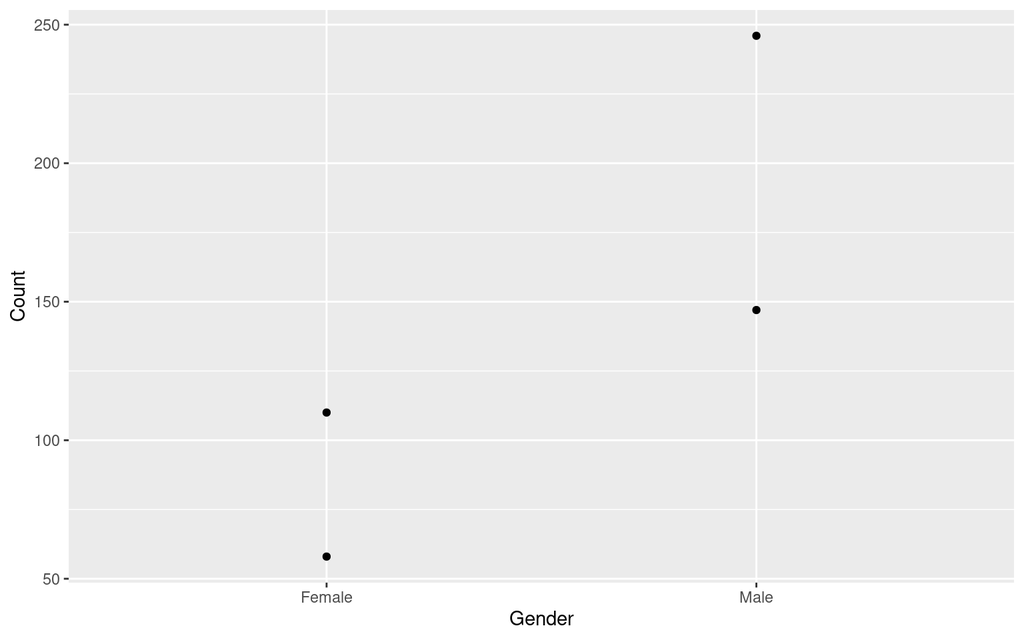

```r
# aplicar el mapping especifico a una capa (mas usado)
ggplot(data = marvelDcGender, mapping = aes(x = Gender, y = Count)) +
  geom_point()
```

### ENRIQUECER EL GRAFICO

Algo que puede ser muy importante para los graficos es cambiar los colores.

Lo que haremos sera que el color dependa de la variable publisher.

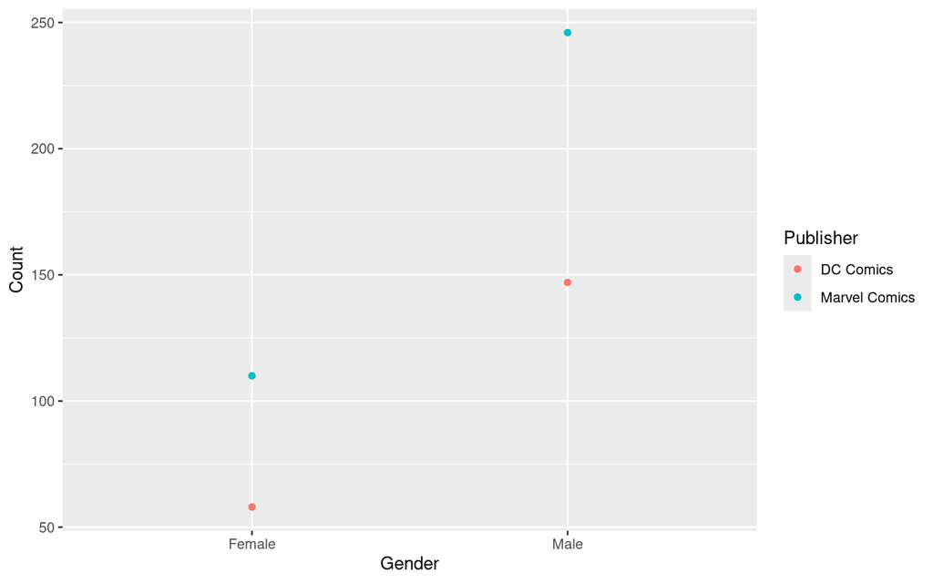

```r
#3. El grafico anterior se puede ir enriqueciendo al agregar atributos esteticos al mapping
# o asignando atributos fuera del mapping. Recordar la diferencia entre el mapping y "setting aesthetics".

#a. Agregar elementos aeshetics al mapping

ggplot(marvelDcGender) + # Hacer que el color dependa de la variable Publisher
  geom_point(mapping = aes(x = Gender, y = Count, colour= Publisher))
```

Si nosotros queremos que un setting sea el color que nosotros queramos solo necesitamos añadir `coulor = "color"`

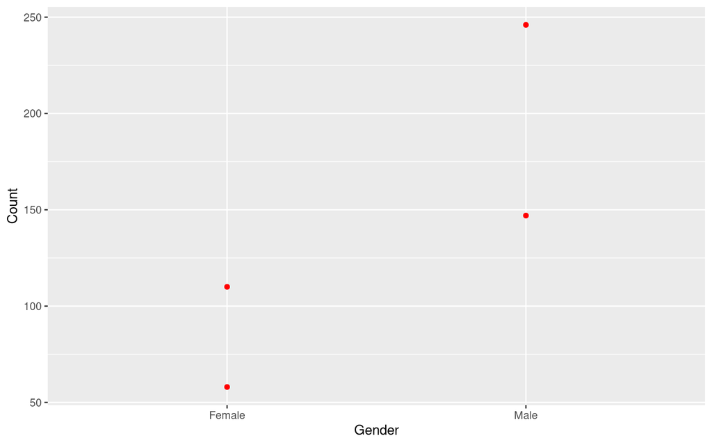

```r
#b. Agregar elementos como setting aesthetics
ggplot(marvelDcGender) +
    geom_point (aes(x = Gender, y = Count), colour="red")
```

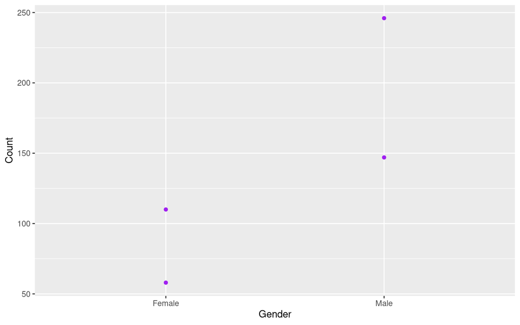

```r
ggplot(marvelDcGender) +
  geom_point (aes(x = Gender, y = Count), colour="purple")
```

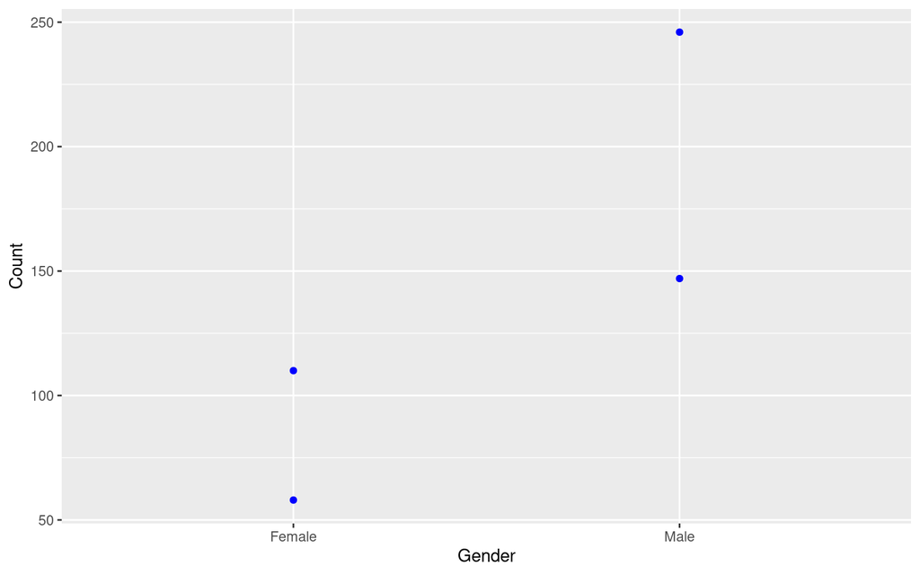

```r
ggplot(marvelDcGender) +
  geom_point (aes(x = Gender, y = Count), colour="blue")
```

## TIPOS DE GEOMETRIAS

Ahora utilizaremos el `data` de infoCharacters, y que visualmente el eje de X sea la altura

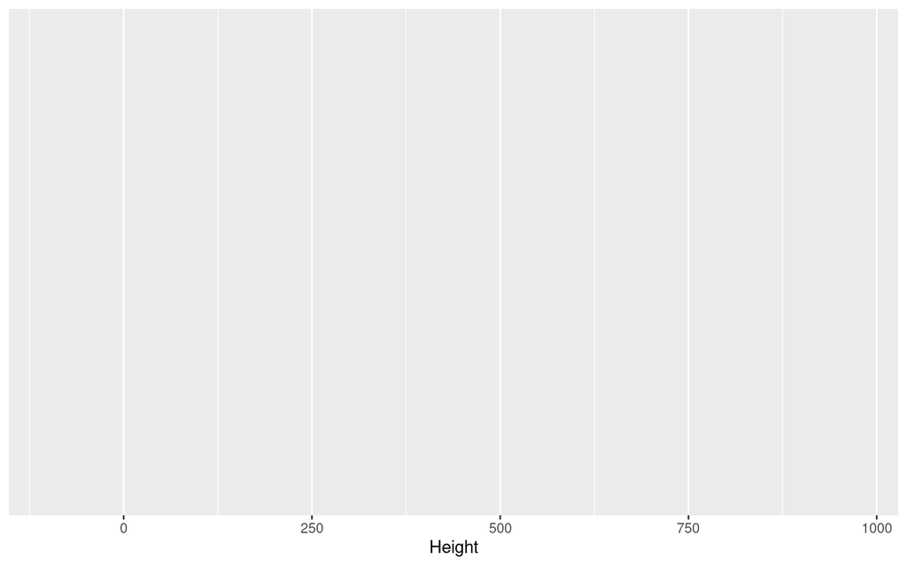

```r
###--- Tipos de geometrias ----

# PALETAS DE COLOR PERSONALIZADAS
dcMarvelPalette <- c("#0476F2", "#EC1E24")
goodBadPalette <- c("#A71D20", "#0DA751", "#818385")


# Para agregar geometrias que representen los datos hay que  utilizar la funcion  geom_
# que se usa en ggplot para representa un grafico por medio de objetos geometricos.
# Y se compone de la palabra geom y luego el nombre de la geometr?a (en ingles).

# ONE VARIABLE continuous (valores)
c <- ggplot(infoCharacters, aes(x = Height))
c
```

El resultado se ve asi porque no se ha definidon la geometria y solo esta involucrado el eje X.

Agregamos diferentes geometrias para probar (Todas las opciones tienen su documentacion).

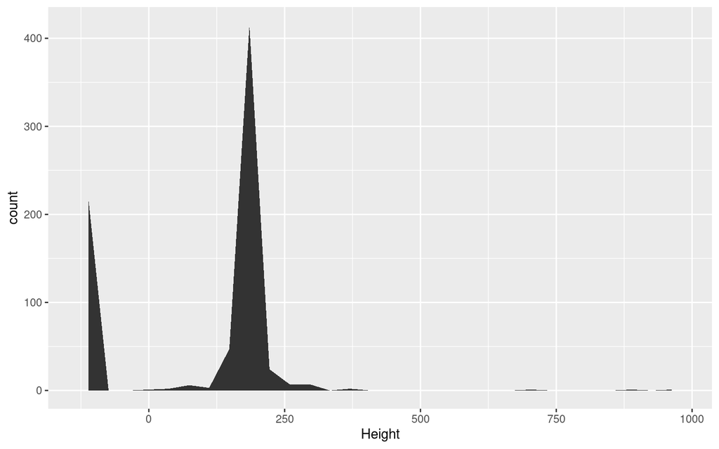

```r
c + geom_area(stat = "bin")
```

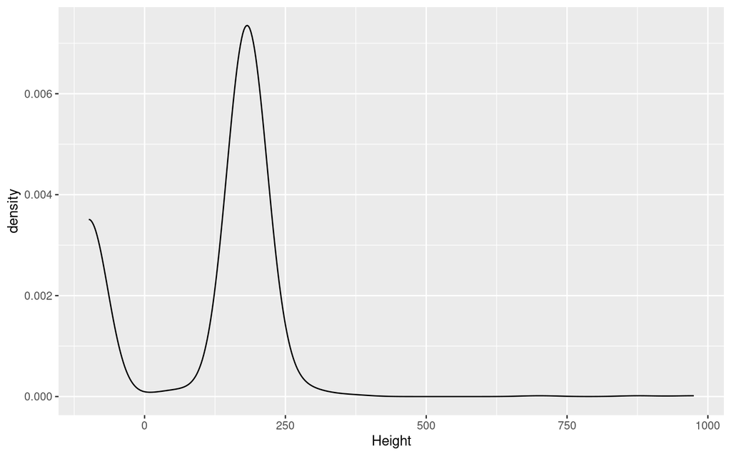

```r
c + geom_density(kernel = "gaussian")
```

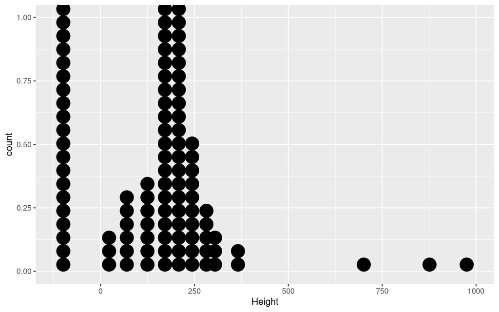

```r
c + geom_dotplot()
```

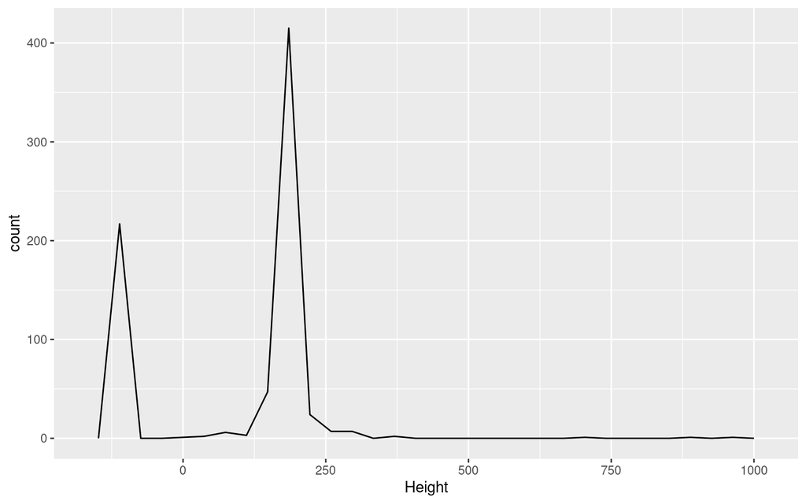

```r
c + geom_freqpoly()
```

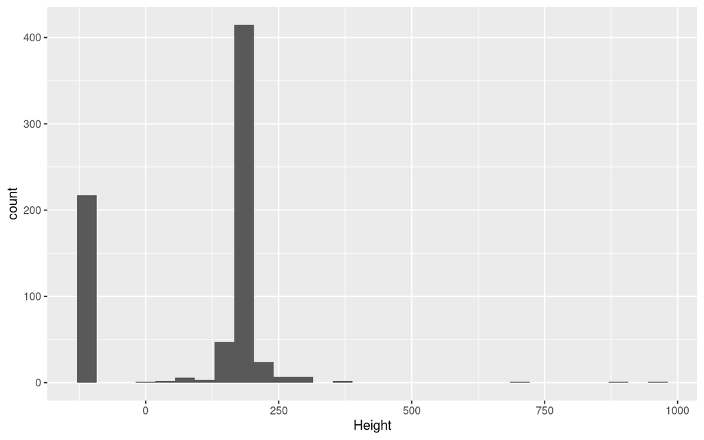

```r
c + geom_histogram()
```

En este caso las opciones le otorgaron al eje y la cantidad de personajes que tienen esa altura.

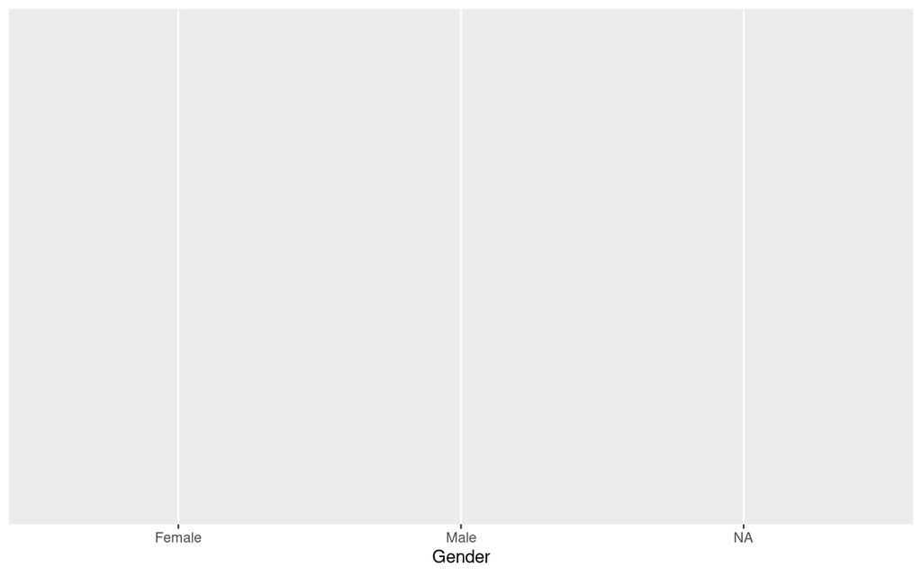

```r
# ONE VARIABLE discrete (cualidades)
d <- ggplot(infoCharacters, aes(x = Gender))
d
```

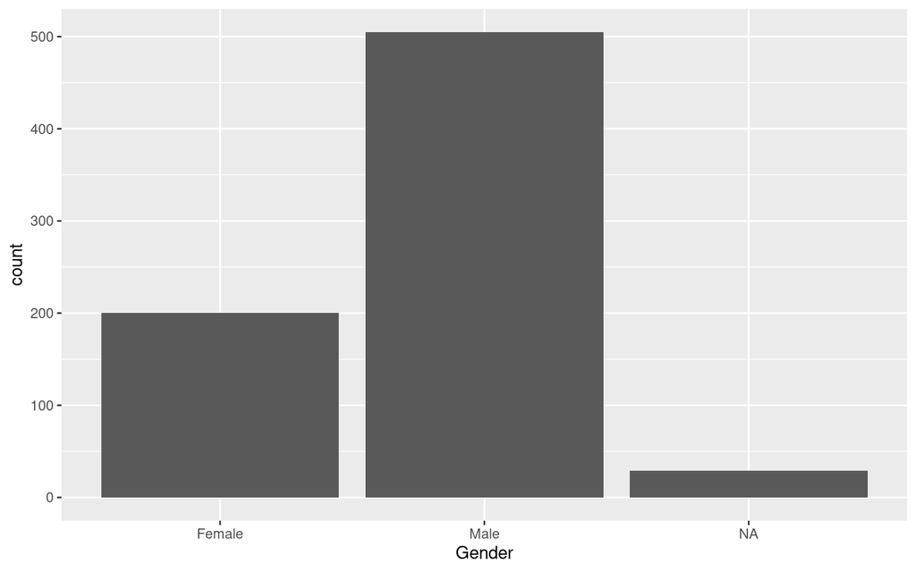

```r
d + geom_bar()
```

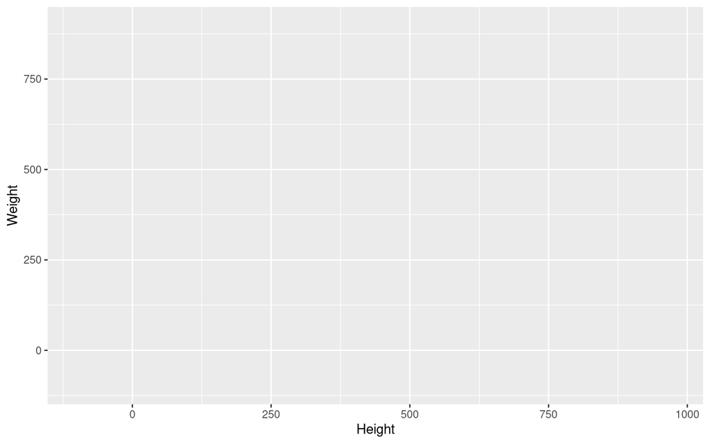

```r
#TWO VARIABLES both continuous
e <- ggplot(data = infoCharacters, aes(x = Height, y = Weight))
e
```

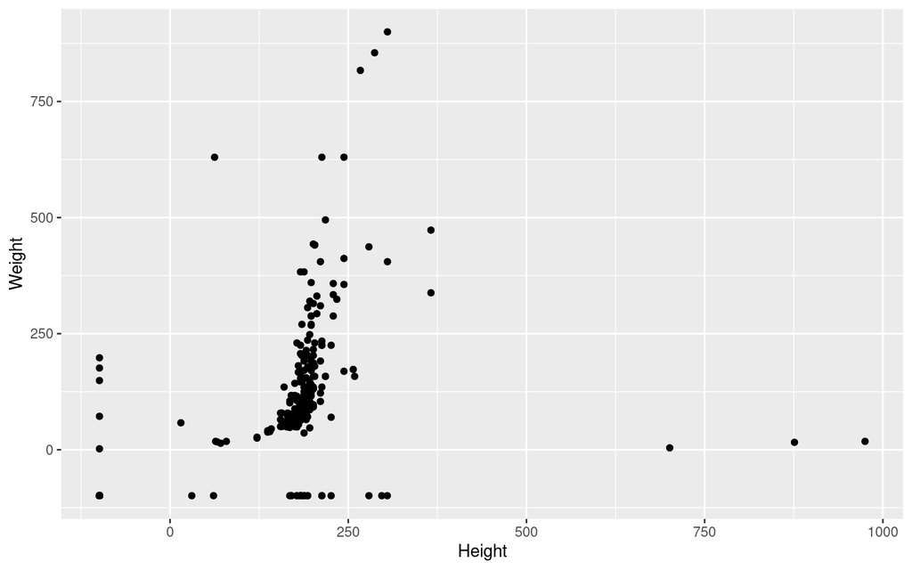

```r
e + geom_point()
```

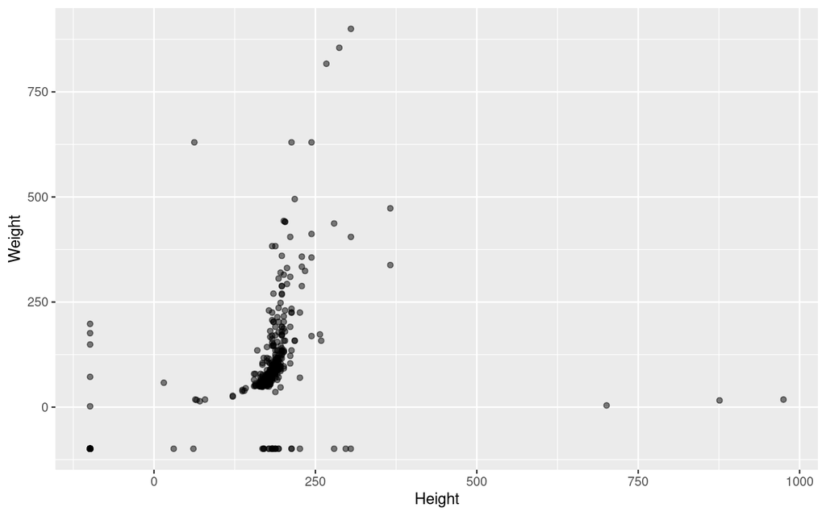

```r
e + geom_point(alpha=0.5)
```

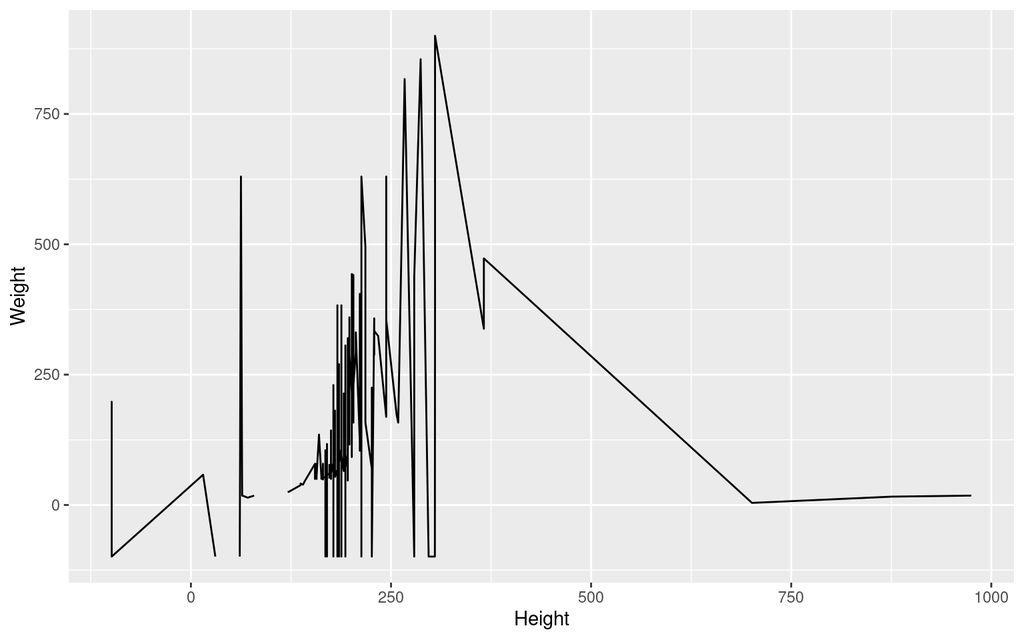

```r
# alpha es para poner transparencia y permite ver entre mas solido
# mas datos presentes

e + geom_line()
```

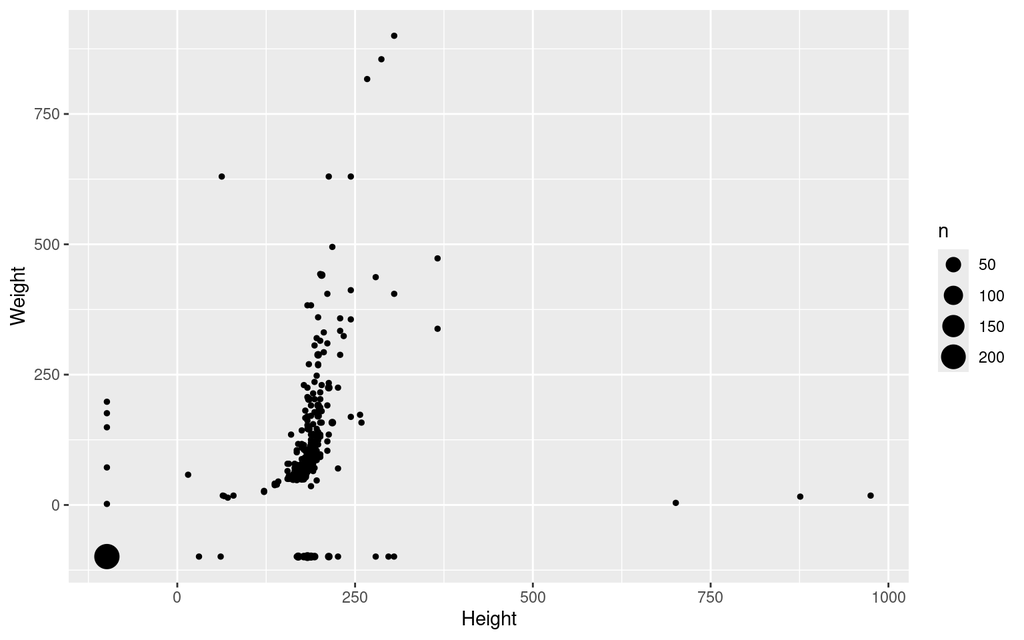

```r
e + geom_count()
```

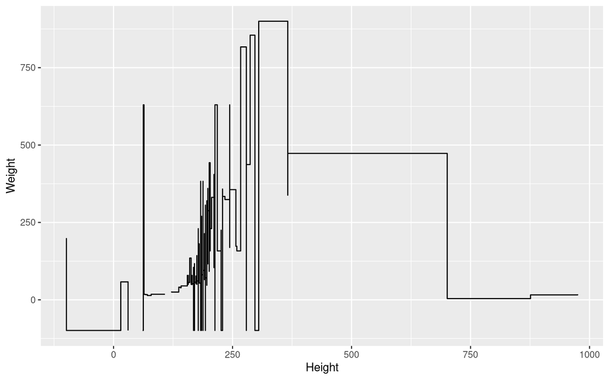

```r
e + geom_step()
```

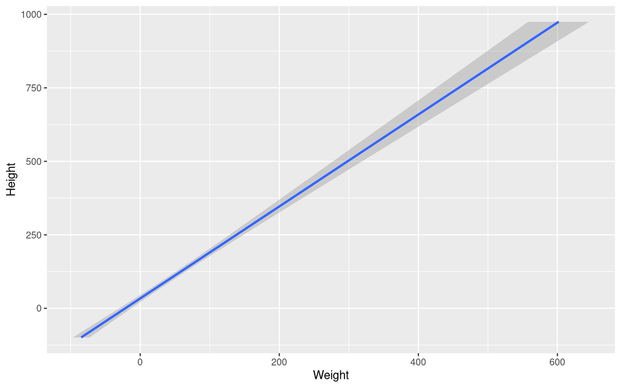

```r
e + geom_smooth(method = lm) + # metodo lineal, regresion lineal
coord_flip() # para voltear x y y
```

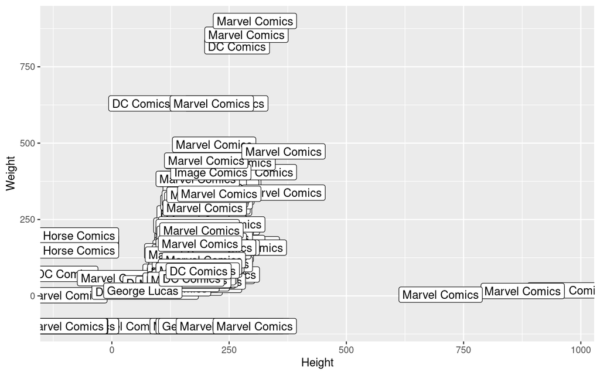

```r
#Etiquetas
e + geom_label(aes(label= Publisher))
```

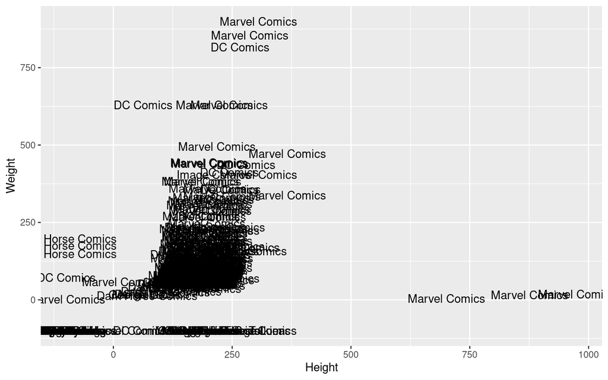

```r
e + geom_text(aes(label= Publisher)) # remplazar puntos por letras
```

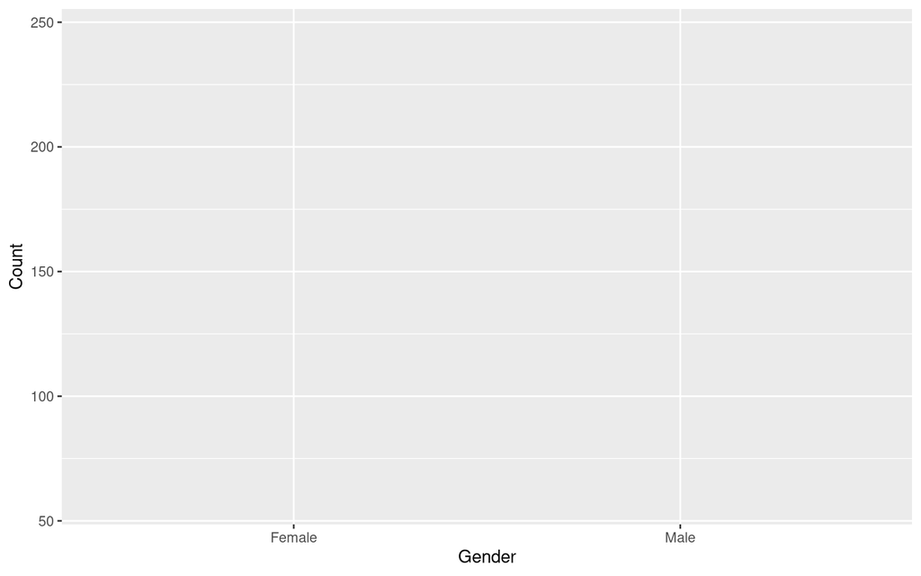

```r
#one discrete, one continuous
f <- ggplot(marvelDcGender, aes(x = Gender, y = Count))
f
```

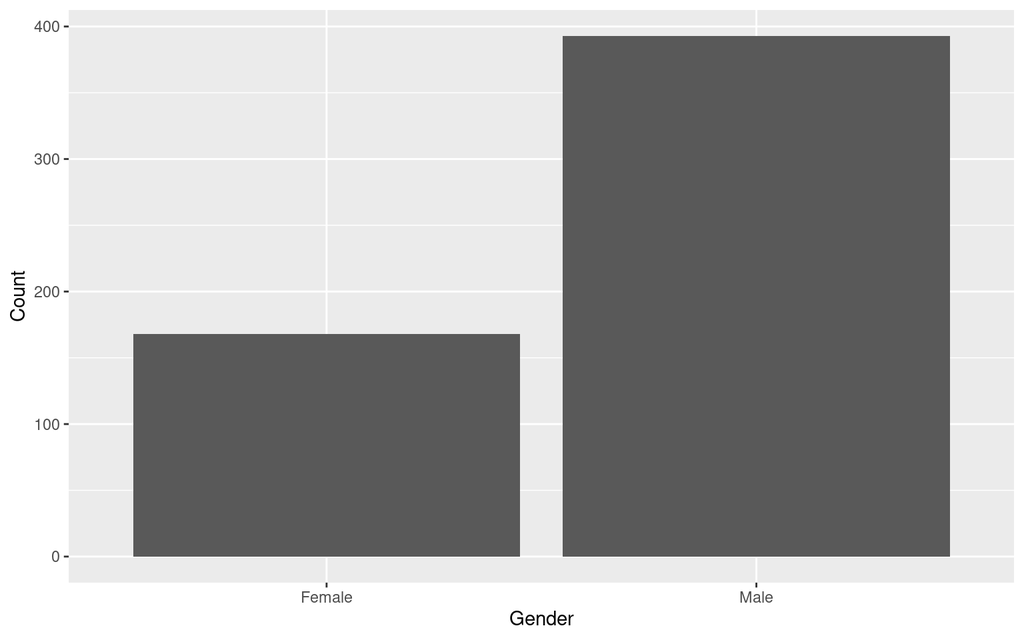

```r
f + geom_col()
```

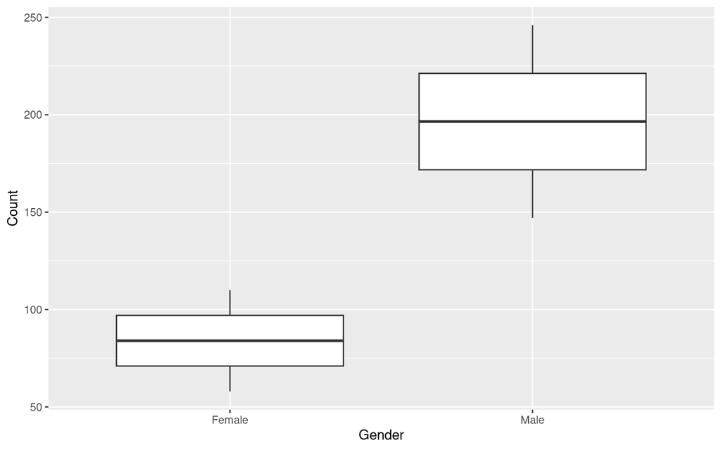

```r
f + geom_boxplot()
```

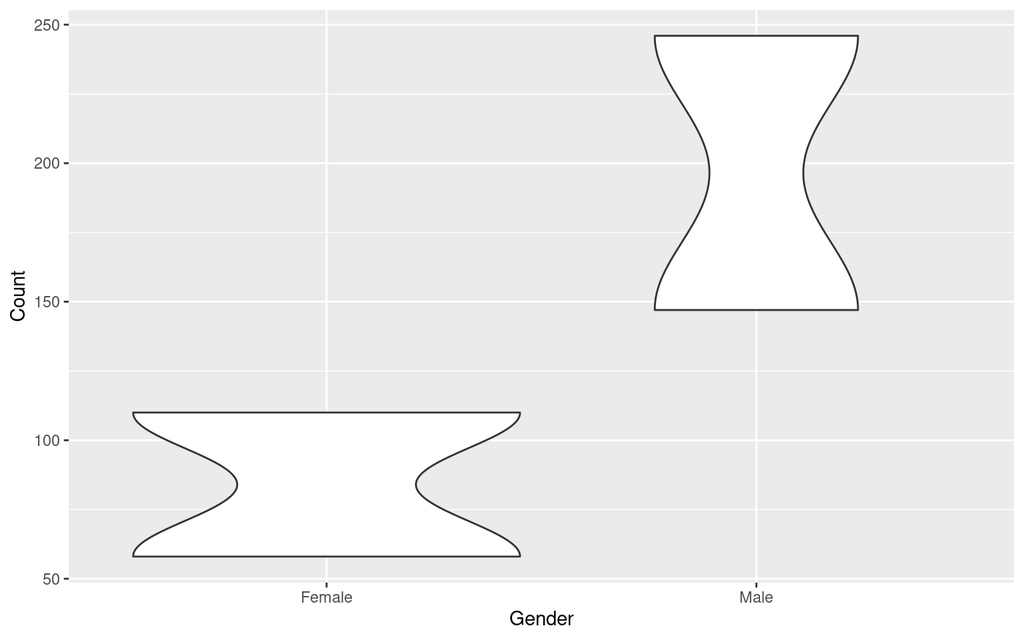

```r
f + geom_violin()
```

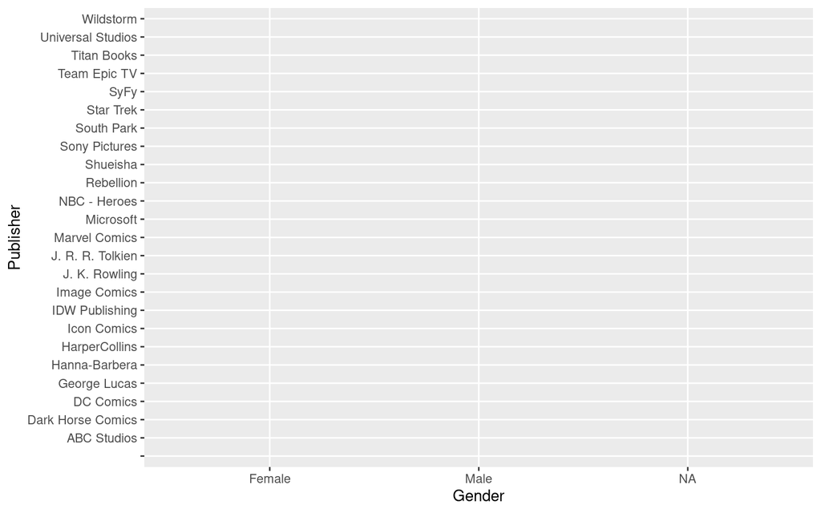

```r
rm(f, e, d, c) #eliminar variables especificas

#both discrete
g <- ggplot(infoCharacters, aes(x = Gender, y = Publisher))
g
```

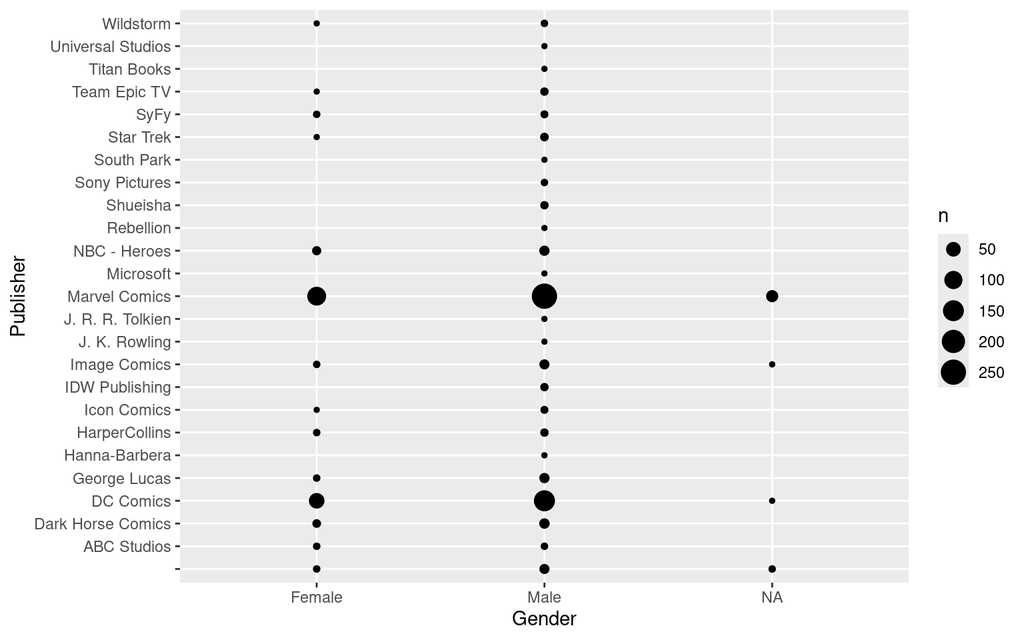

```r
g + geom_count()
```

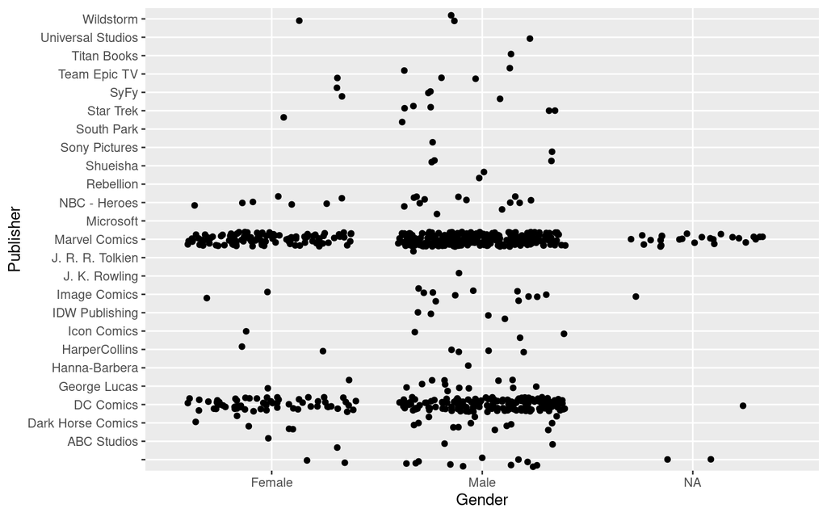

```r
g + geom_jitter()
```